# 5. Applied Regression III

2023-02-28

> [*Back to content page*](https://flatter11.github.io/r.studio/)

Learning objectives

- Identify and handle multicollinearity
- Account for confounding factors in regression model
- Assess potential effect modifiers in regression model
- Perform basic mediation analysis

# 1 Multicollinearity

- **Collinearity** = strong linear dependency/high correlation between two predictor variables (X1 and X2)
  - Collinear variables give similar information, e.g. personal income and household income
  - For **perfect collinearity** between two predictor variables X1 and X2. We can find constants a, b so that $X_1 = a + bX_2$ , e.g. X1 = degree in Celsius, X2 = degree in Fahrenheit
- **Multicollinearity:** Predictor variable strongly depends on other predictor variables linearly, e.g. X<sub>4</sub> = a + b<sub>1</sub>X<sub>1</sub> + b<sub>2</sub>X<sub>2</sub> + b<sub>3</sub>X<sub>3</sub> has a very good fit
- Multicollinearity does not violate any of the assumptions of linear regression model BUT
  - e.g. for perfectly correlated predictors $X_1 = a + bX_2$
  - $Y = α + β_1X_1 + β_2X_2 = (α + aβ_1) + (bβ_1 + β_2)X_2$.
  - We can always find different sets of (α, β1, β2) to represent exactly the same relation –> inflates standard error of the estimated coefficients β –> **Uncertainty in estimated coefficients β is large**

#### Example: MVC

- Suppose we create a new variable ‘height.sq’ which is the square of the heights
- We fit the linear regression model including height.sq:

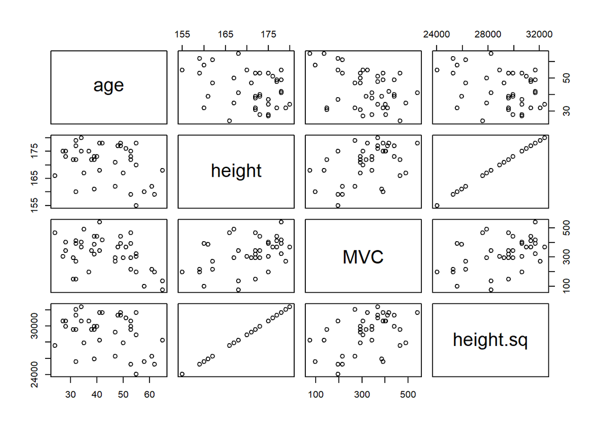

```r
mvc <- read.csv("Folder/mvc.csv")
mvc$height.sq <- mvc$height^2 #create a new variable
pairs(mvc) #We can see taht height and height.sq is highly correlated (45 degree line)
```

```r
summary(lm(MVC~age+height, data=mvc)) #Standard error is 2.545
summary(lm(MVC~age+height+height.sq, data=mvc)) #If we have multicollinearity, the standard error become very big (127.8036)
```

[output not shown]

## 1.1 Diagnostics

- For pairwise collinearity, use scatterplot to plot between all predictor variables
- For multicollinearity, use **Variance inflation factor (VIF)** – require the “car” package `vif(model)`
  - VIF<sub>j</sub> = 1 / (1 – R<sub>j</sub><sup>2</sup>) where R<sub>j</sub><sup>2</sup> is the R<sup>2</sup> when predictor X<sub>j</sub> is regressed on all other predictors (e.g., R<sup>2</sup> when X<sub>1</sub> is regressed on X<sub>2</sub>, X<sub>3</sub>, X<sub>4</sub>) –> when R<sub>j</sub><sup>2</sup> is large (have collinearity), VIF is very large
  - Threshold: **VIF > 10** = potential multicollinearity problem

```r
require(car)
mvc.lm3 <- lm(MVC~age+height+height.sq, data=mvc)
vif(mvc.lm3) #Very large VIF for the height terms --> multicollinearity
```

```
##         age      height   height.sq
##    1.140494 2788.043855 2784.139173
```

## 1.2 Solution

- Do nothing coz estimated coefficients are still unbiased
  - But be careful coz inefficient estimation (very big standard error) – Affect the main objectives of the analysis?
- In practice
  1. Increase the sample size at planning stage
  2. Centering (only for polynomial terms and interactions, doesn’t help other collinearity problem)  
     Subtract the mean values from the variable (i.e. $X \rightarrow X - \overline{X}$ or $X^{2} \rightarrow (X - \overline{X})^{2}$ )  
     `scale (x, scale=F)`
     1. **x** is the centered object
     2. **scale** = T: x is divided by standard deviations (but no need this so we set it as F)
  3. Drop one or more variables causing multicollinearity  
     Most appropriate when two variables basically measure the same thing Problematic if the variable is an important confounder

```r
##Centering
mvc$ct.height <- scale(mvc$height, scale=F) #Generate centered height
mvc$ct.height.sq <- mvc$ct.height^2 #Generate centered height square
mvc.lm4 <- lm(MVC~age+ct.height+ct.height.sq, data=mvc)
vif(mvc.lm4) #VIF is much lower after centering
```

```
##          age    ct.height ct.height.sq
##     1.140494     1.603104     1.534462
```

```r
#Note that R2 is the same as before coz we just transform the variables
```

## Other potential problems in regression models

1. Multilevel structure  
   E.g., correlation within hospital or ward (Patients in the same ward will be similar)  
   Need to fit **multi-level models** to account for multilevel structure
2. Measurement error  
   Imprecise measurement in predictors will **attenuate estimated coefficients** toward zero (close to null value) –> need to be careful